# dplyr tutorial

Doro Hodapp

24 January 2017

## Why use dplyr?

It is great for data exploration and manipulation when using data frames. Generally, any operation you do with dplyr commands could also be performed using one of the R base commands, but dplyr is more intuitive to write, requires less coding and is easier to read, especially when coming back to code you have written a while ago.  
It allows you to work with data frames, data tables and remote databases by using the same set of functions.

If you also use the plyr package, load plyr first.

Below I have compiled code and examples from a dplyr tutorial written by Hadley Wickham with additional comments and explanations. The original R files you can find [here](https://www.dropbox.com/sh/i8qnluwmuieicxc/AAAgt9tIKoIm7WZKIyK25lh6a).

First, load data of every flight departing from Houston in 2011 and convert to so called local data frame (Local data frame is simply a wrapper for a data frame that prints nicely).

```r
#load required packages
library(dplyr)
library(ggplot2)

flights <- tbl_df(read.csv("flights.csv", stringsAsFactors = FALSE))
flights$date <- as.Date(flights$date)
dim(flights)
```

```
## [1] 227496     14
```

Load remaining data sets on hourly weather data, plane metadata and airport metadata. Display top of data frames.

```r
weather <- tbl_df(read.csv("weather.csv", stringsAsFactors = FALSE))
weather$date <- as.Date(weather$date)
dim(weather)
```

```
## [1] 8723   14
```

```r
planes <- tbl_df(read.csv("planes.csv", stringsAsFactors = FALSE))

airports <- tbl_df(read.csv("airports.csv", stringsAsFactors = FALSE))

flights
```

```
## # A tibble: 227,496 × 14
##          date  hour minute   dep   arr dep_delay arr_delay carrier flight
##        <date> <int>  <int> <int> <int>     <int>     <int>   <chr>  <int>
## 1  2011-01-01    14      0  1400  1500         0       -10      AA    428
## 2  2011-01-02    14      1  1401  1501         1        -9      AA    428
## 3  2011-01-03    13     52  1352  1502        -8        -8      AA    428
## 4  2011-01-04    14      3  1403  1513         3         3      AA    428
## 5  2011-01-05    14      5  1405  1507         5        -3      AA    428
## 6  2011-01-06    13     59  1359  1503        -1        -7      AA    428
## 7  2011-01-07    13     59  1359  1509        -1        -1      AA    428
## 8  2011-01-08    13     55  1355  1454        -5       -16      AA    428
## 9  2011-01-09    14     43  1443  1554        43        44      AA    428
## 10 2011-01-10    14     43  1443  1553        43        43      AA    428
## # ... with 227,486 more rows, and 5 more variables: dest <chr>,
## #   plane <chr>, cancelled <int>, time <int>, dist <int>
```

```r
weather
```

```
## # A tibble: 8,723 × 14
##          date  hour  temp dew_point humidity pressure visibility wind_dir
##        <date> <int> <dbl>     <dbl>    <int>    <dbl>      <dbl>    <chr>
## 1  2011-01-01     0  59.0      28.9       32    29.86         10      NNE
## 2  2011-01-01     1  57.2      28.4       33    29.88         10      NNE
## 3  2011-01-01     2  55.4      28.4       36    29.93         10      NNW
## 4  2011-01-01     3  53.6      28.4       38    29.94         10    North
## 5  2011-01-01     4    NA        NA       NA    29.99         10      NNW
## 6  2011-01-01     5    NA        NA       NA    30.02         10    North
## 7  2011-01-01     6  53.1      17.1       24    30.05         10    North
## 8  2011-01-01     7  53.1      16.0       23    30.07         10    North
## 9  2011-01-01     8  54.0      18.0       24    30.09         10    North
## 10 2011-01-01     9  55.4      17.6       23    30.09         10      NNE
## # ... with 8,713 more rows, and 6 more variables: wind_dir2 <int>,
## #   wind_speed <dbl>, gust_speed <dbl>, precip <dbl>, conditions <chr>,
## #   events <chr>
```

```r
planes
```

```
## # A tibble: 2,853 × 9
##     plane  year               mfr          model no.eng no.seats speed
##     <chr> <int>             <chr>          <chr>  <int>    <int> <int>
## 1  N576AA  1991 MCDONNELL DOUGLAS DC-9-82(MD-82)      2      172    NA
## 2  N557AA  1993        MARZ BARRY      KITFOX IV      1        2    NA
## 3  N403AA  1974             RAVEN           S55A     NA        1    60
## 4  N492AA  1989 MCDONNELL DOUGLAS DC-9-82(MD-82)      2      172    NA
## 5  N262AA  1985 MCDONNELL DOUGLAS DC-9-82(MD-82)      2      172    NA
## 6  N493AA  1989 MCDONNELL DOUGLAS DC-9-82(MD-82)      2      172    NA
## 7  N477AA  1988 MCDONNELL DOUGLAS DC-9-82(MD-82)      2      172    NA
## 8  N476AA  1988 MCDONNELL DOUGLAS DC-9-82(MD-82)      2      172    NA
## 9  N504AA    NA AUTHIER ANTHONY P      TIERRA II      1        2    NA
## 10 N565AA  1987 MCDONNELL DOUGLAS DC-9-83(MD-83)      2      172    NA
## # ... with 2,843 more rows, and 2 more variables: engine <chr>, type <chr>
```

```r
airports
```

```
## # A tibble: 3,376 × 7
##     iata              airport             city state country      lat
##    <chr>                <chr>            <chr> <chr>   <chr>    <dbl>
## 1    00M             Thigpen       Bay Springs    MS     USA 31.95376
## 2    00R Livingston Municipal       Livingston    TX     USA 30.68586
## 3    00V          Meadow Lake Colorado Springs    CO     USA 38.94575
## 4    01G         Perry-Warsaw            Perry    NY     USA 42.74135
## 5    01J     Hilliard Airpark         Hilliard    FL     USA 30.68801
## 6    01M    Tishomingo County          Belmont    MS     USA 34.49167
## 7    02A          Gragg-Wade           Clanton    AL     USA 32.85049
## 8    02C              Capitol       Brookfield    WI     USA 43.08751
## 9    02G    Columbiana County   East Liverpool    OH     USA 40.67331
## 10   03D     Memphis Memorial          Memphis    MO     USA 40.44726
## # ... with 3,366 more rows, and 1 more variables: long <dbl>
```

To get your data into an adequate format you can use the tidyr functions: gather(), spread() and separate(). Main idea of tidy data is that all your variables are arranged in columns. Read more about tidyr and format of stored data [here](http://vita.had.co.nz/papers/tidy-data.pdf).

In principle, everything you need to arrange and manipulate your data are a small set of basic commands. So to manipulate your data you will only have to think about which of the following commands will do what you need:

- Basic commands:
- filter(): select rows based on certain criteria matching their values
- select(): select certain columns
- arrange(): reorder rows and columns of your data frame
- mutate(): add new variables to your data frame
- summarise(): apply functions (summary statistics) to your data
- Some more useful commands:
- group_by(): group data by a variable and operate further functions on the grouped data
- slice(): select rows by position
- transmute: similar to mutate, create new variables based on existing ones, but only keep the newly created ones
- sample_n(): select random rows from a table
- sample_frac(): randomly select a certain fraction of rows from a table

The command structure for all dplyr verbs is always:  
The first argument is a data frame.  
Subsequent arguments define what to do with the data.  
The return value is a data frame.  
Nothing is modified in place.

### filter()

```r
# select all flights to LOs Angeles
filter(flights, dest == "LAX")
```

```
## # A tibble: 6,064 × 14
##          date  hour minute   dep   arr dep_delay arr_delay carrier flight
##        <date> <int>  <int> <int> <int>     <int>     <int>   <chr>  <int>
## 1  2011-01-31    19     16  1916  2103         6         2      CO     47
## 2  2011-01-31     7     47   747   936         2         5      CO     52
## 3  2011-01-31    14     33  1433  1629         5        14      CO    137
## 4  2011-01-31    15     50  1550  1736        10         8      CO    795
## 5  2011-01-31    21      7  2107  2247        12         7      CO   1095
## 6  2011-01-31     9     20   920  1116        -5         5      CO   1495
## 7  2011-01-31    11     53  1153  1353         3        18      CO   1605
## 8  2011-01-31    13     25  1325  1538        10        32      CO   1695
## 9  2011-01-31    17     49  1749  1938         4         6      CO   1795
## 10 2011-01-30    19     14  1914  2125         3        23      CO     47
## # ... with 6,054 more rows, and 5 more variables: dest <chr>, plane <chr>,
## #   cancelled <int>, time <int>, dist <int>
```

```r
# view the latest result in a separate window
#.Last.value %>% View()

# select all flights with destination LA that were cancelled
filter(flights, dest == "LAX" , cancelled == 1)
```

```
## # A tibble: 33 × 14
##          date  hour minute   dep   arr dep_delay arr_delay carrier flight
##        <date> <int>  <int> <int> <int>     <int>     <int>   <chr>  <int>
## 1  2011-02-09    NA     NA    NA    NA        NA        NA      CO    137
## 2  2011-02-09    NA     NA    NA    NA        NA        NA      CO   1795
## 3  2011-02-04    NA     NA    NA    NA        NA        NA      CO     52
## 4  2011-02-04    NA     NA    NA    NA        NA        NA      CO    137
## 5  2011-02-04    NA     NA    NA    NA        NA        NA      CO   1495
## 6  2011-02-04    NA     NA    NA    NA        NA        NA      CO   1605
## 7  2011-02-04    NA     NA    NA    NA        NA        NA      CO   1695
## 8  2011-02-04    NA     NA    NA    NA        NA        NA      CO   1795
## 9  2011-02-03    NA     NA    NA    NA        NA        NA      CO     47
## 10 2011-02-03    NA     NA    NA    NA        NA        NA      CO   1095
## # ... with 23 more rows, and 5 more variables: dest <chr>, plane <chr>,
## #   cancelled <int>, time <int>, dist <int>
```

```r
# you can also use boolean operators (|, &)
filter(flights, dest == "LAX" & cancelled == 1)
```

```
## # A tibble: 33 × 14
##          date  hour minute   dep   arr dep_delay arr_delay carrier flight
##        <date> <int>  <int> <int> <int>     <int>     <int>   <chr>  <int>
## 1  2011-02-09    NA     NA    NA    NA        NA        NA      CO    137
## 2  2011-02-09    NA     NA    NA    NA        NA        NA      CO   1795
## 3  2011-02-04    NA     NA    NA    NA        NA        NA      CO     52
## 4  2011-02-04    NA     NA    NA    NA        NA        NA      CO    137
## 5  2011-02-04    NA     NA    NA    NA        NA        NA      CO   1495
## 6  2011-02-04    NA     NA    NA    NA        NA        NA      CO   1605
## 7  2011-02-04    NA     NA    NA    NA        NA        NA      CO   1695
## 8  2011-02-04    NA     NA    NA    NA        NA        NA      CO   1795
## 9  2011-02-03    NA     NA    NA    NA        NA        NA      CO     47
## 10 2011-02-03    NA     NA    NA    NA        NA        NA      CO   1095
## # ... with 23 more rows, and 5 more variables: dest <chr>, plane <chr>,
## #   cancelled <int>, time <int>, dist <int>
```

```r
filter(flights, dest == "LAX" & dep_delay > 30)
```

```
## # A tibble: 696 × 14
##          date  hour minute   dep   arr dep_delay arr_delay carrier flight
##        <date> <int>  <int> <int> <int>     <int>     <int>   <chr>  <int>
## 1  2011-01-30    13     19  1319  1515        40        51      CO   1605
## 2  2011-01-28    17      9  1709  1833        89        65      CO    795
## 3  2011-01-28    15      4  1504  1622       109        76      CO   1695
## 4  2011-01-27    18     22  1822  1945       234       210      CO    137
## 5  2011-01-27    21     34  2134  2253        39        13      CO   1095
## 6  2011-01-25    18     23  1823  1950        38        18      CO   1795
## 7  2011-01-22    15     10  1510  1648        42        33      CO    137
## 8  2011-01-22    14     14  1414  1546        44        30      CO   1695
## 9  2011-01-20    19     57  1957  2139        43        34      CO     47
## 10 2011-01-20    16     28  1628  1836        48        68      CO    795
## # ... with 686 more rows, and 5 more variables: dest <chr>, plane <chr>,
## #   cancelled <int>, time <int>, dist <int>
```

```r
filter(flights, dest == "LAX" | dest == "DFW")
```

```
## # A tibble: 12,717 × 14
##          date  hour minute   dep   arr dep_delay arr_delay carrier flight
##        <date> <int>  <int> <int> <int>     <int>     <int>   <chr>  <int>
## 1  2011-01-01    14      0  1400  1500         0       -10      AA    428
## 2  2011-01-02    14      1  1401  1501         1        -9      AA    428
## 3  2011-01-03    13     52  1352  1502        -8        -8      AA    428
## 4  2011-01-04    14      3  1403  1513         3         3      AA    428
## 5  2011-01-05    14      5  1405  1507         5        -3      AA    428
## 6  2011-01-06    13     59  1359  1503        -1        -7      AA    428
## 7  2011-01-07    13     59  1359  1509        -1        -1      AA    428
## 8  2011-01-08    13     55  1355  1454        -5       -16      AA    428
## 9  2011-01-09    14     43  1443  1554        43        44      AA    428
## 10 2011-01-10    14     43  1443  1553        43        43      AA    428
## # ... with 12,707 more rows, and 5 more variables: dest <chr>,
## #   plane <chr>, cancelled <int>, time <int>, dist <int>
```

```r
filter(flights, dest %in% c("LAX","DFW"))
```

```
## # A tibble: 12,717 × 14
##          date  hour minute   dep   arr dep_delay arr_delay carrier flight
##        <date> <int>  <int> <int> <int>     <int>     <int>   <chr>  <int>
## 1  2011-01-01    14      0  1400  1500         0       -10      AA    428
## 2  2011-01-02    14      1  1401  1501         1        -9      AA    428
## 3  2011-01-03    13     52  1352  1502        -8        -8      AA    428
## 4  2011-01-04    14      3  1403  1513         3         3      AA    428
## 5  2011-01-05    14      5  1405  1507         5        -3      AA    428
## 6  2011-01-06    13     59  1359  1503        -1        -7      AA    428
## 7  2011-01-07    13     59  1359  1509        -1        -1      AA    428
## 8  2011-01-08    13     55  1355  1454        -5       -16      AA    428
## 9  2011-01-09    14     43  1443  1554        43        44      AA    428
## 10 2011-01-10    14     43  1443  1553        43        43      AA    428
## # ... with 12,707 more rows, and 5 more variables: dest <chr>,
## #   plane <chr>, cancelled <int>, time <int>, dist <int>
```

```r
# find all flights in January
filter(flights, date < "2011-02-01")
```

```
## # A tibble: 18,910 × 14
##          date  hour minute   dep   arr dep_delay arr_delay carrier flight
##        <date> <int>  <int> <int> <int>     <int>     <int>   <chr>  <int>
## 1  2011-01-01    14      0  1400  1500         0       -10      AA    428
## 2  2011-01-02    14      1  1401  1501         1        -9      AA    428
## 3  2011-01-03    13     52  1352  1502        -8        -8      AA    428
## 4  2011-01-04    14      3  1403  1513         3         3      AA    428
## 5  2011-01-05    14      5  1405  1507         5        -3      AA    428
## 6  2011-01-06    13     59  1359  1503        -1        -7      AA    428
## 7  2011-01-07    13     59  1359  1509        -1        -1      AA    428
## 8  2011-01-08    13     55  1355  1454        -5       -16      AA    428
## 9  2011-01-09    14     43  1443  1554        43        44      AA    428
## 10 2011-01-10    14     43  1443  1553        43        43      AA    428
## # ... with 18,900 more rows, and 5 more variables: dest <chr>,
## #   plane <chr>, cancelled <int>, time <int>, dist <int>
```

```r
# find all flights that departed between midnight and 5am
filter(flights, hour >= 0, hour <= 5)
```

```
## # A tibble: 2,532 × 14
##          date  hour minute   dep   arr dep_delay arr_delay carrier flight
##        <date> <int>  <int> <int> <int>     <int>     <int>   <chr>  <int>
## 1  2011-01-01     5     57   557   906        -3        -9      AA   1994
## 2  2011-01-02     5     54   554   912        -6        -3      AA   1994
## 3  2011-01-03     5     55   555   905        -5       -10      AA   1994
## 4  2011-01-04     5     58   558   923        -2         8      AA   1994
## 5  2011-01-05     5     55   555   914        -5        -1      AA   1994
## 6  2011-01-07     5     56   556   905        -4       -10      AA   1994
## 7  2011-01-08     5     58   558   910        -2        -5      AA   1994
## 8  2011-01-09     5     58   558   911        -2        -4      AA   1994
## 9  2011-01-11     5     53   553  1216        -7        NA      AA   1994
## 10 2011-01-12     5     51   551   903        -9       -12      AA   1994
## # ... with 2,522 more rows, and 5 more variables: dest <chr>, plane <chr>,
## #   cancelled <int>, time <int>, dist <int>
```

```r
# to select rows by position use slice()
slice(flights, 1:10)
```

```
## # A tibble: 10 × 14
##          date  hour minute   dep   arr dep_delay arr_delay carrier flight
##        <date> <int>  <int> <int> <int>     <int>     <int>   <chr>  <int>
## 1  2011-01-01    14      0  1400  1500         0       -10      AA    428
## 2  2011-01-02    14      1  1401  1501         1        -9      AA    428
## 3  2011-01-03    13     52  1352  1502        -8        -8      AA    428
## 4  2011-01-04    14      3  1403  1513         3         3      AA    428
## 5  2011-01-05    14      5  1405  1507         5        -3      AA    428
## 6  2011-01-06    13     59  1359  1503        -1        -7      AA    428
## 7  2011-01-07    13     59  1359  1509        -1        -1      AA    428
## 8  2011-01-08    13     55  1355  1454        -5       -16      AA    428
## 9  2011-01-09    14     43  1443  1554        43        44      AA    428
## 10 2011-01-10    14     43  1443  1553        43        43      AA    428
## # ... with 5 more variables: dest <chr>, plane <chr>, cancelled <int>,
## #   time <int>, dist <int>
```

```r
# with r base functions you would write for example..
flights[flights$dest == "LAX" & flights$cancelled == 1, ]
```

```
## # A tibble: 33 × 14
##          date  hour minute   dep   arr dep_delay arr_delay carrier flight
##        <date> <int>  <int> <int> <int>     <int>     <int>   <chr>  <int>
## 1  2011-02-09    NA     NA    NA    NA        NA        NA      CO    137
## 2  2011-02-09    NA     NA    NA    NA        NA        NA      CO   1795
## 3  2011-02-04    NA     NA    NA    NA        NA        NA      CO     52
## 4  2011-02-04    NA     NA    NA    NA        NA        NA      CO    137
## 5  2011-02-04    NA     NA    NA    NA        NA        NA      CO   1495
## 6  2011-02-04    NA     NA    NA    NA        NA        NA      CO   1605
## 7  2011-02-04    NA     NA    NA    NA        NA        NA      CO   1695
## 8  2011-02-04    NA     NA    NA    NA        NA        NA      CO   1795
## 9  2011-02-03    NA     NA    NA    NA        NA        NA      CO     47
## 10 2011-02-03    NA     NA    NA    NA        NA        NA      CO   1095
## # ... with 23 more rows, and 5 more variables: dest <chr>, plane <chr>,
## #   cancelled <int>, time <int>, dist <int>
```

### select()

```r
# select certain columns
select(flights, dep:arr_delay,dest,plane)
```

```
## # A tibble: 227,496 × 6
##      dep   arr dep_delay arr_delay  dest  plane
##    <int> <int>     <int>     <int> <chr>  <chr>
## 1   1400  1500         0       -10   DFW N576AA
## 2   1401  1501         1        -9   DFW N557AA
## 3   1352  1502        -8        -8   DFW N541AA
## 4   1403  1513         3         3   DFW N403AA
## 5   1405  1507         5        -3   DFW N492AA
## 6   1359  1503        -1        -7   DFW N262AA
## 7   1359  1509        -1        -1   DFW N493AA
## 8   1355  1454        -5       -16   DFW N477AA
## 9   1443  1554        43        44   DFW N476AA
## 10  1443  1553        43        43   DFW N504AA
## # ... with 227,486 more rows
```

```r
select(flights, -(dep:arr_delay))
```

```
## # A tibble: 227,496 × 10
##          date  hour minute carrier flight  dest  plane cancelled  time
##        <date> <int>  <int>   <chr>  <int> <chr>  <chr>     <int> <int>
## 1  2011-01-01    14      0      AA    428   DFW N576AA         0    40
## 2  2011-01-02    14      1      AA    428   DFW N557AA         0    45
## 3  2011-01-03    13     52      AA    428   DFW N541AA         0    48
## 4  2011-01-04    14      3      AA    428   DFW N403AA         0    39
## 5  2011-01-05    14      5      AA    428   DFW N492AA         0    44
## 6  2011-01-06    13     59      AA    428   DFW N262AA         0    45
## 7  2011-01-07    13     59      AA    428   DFW N493AA         0    43
## 8  2011-01-08    13     55      AA    428   DFW N477AA         0    40
## 9  2011-01-09    14     43      AA    428   DFW N476AA         0    41
## 10 2011-01-10    14     43      AA    428   DFW N504AA         0    45
## # ... with 227,486 more rows, and 1 more variables: dist <int>
```

```r
select(flights, starts_with("arr"))
```

```
## # A tibble: 227,496 × 2
##      arr arr_delay
##    <int>     <int>
## 1   1500       -10
## 2   1501        -9
## 3   1502        -8
## 4   1513         3
## 5   1507        -3
## 6   1503        -7
## 7   1509        -1
## 8   1454       -16
## 9   1554        44
## 10  1553        43
## # ... with 227,486 more rows
```

```r
select(flights, ends_with("delay"))
```

```
## # A tibble: 227,496 × 2
##    dep_delay arr_delay
##        <int>     <int>
## 1          0       -10
## 2          1        -9
## 3         -8        -8
## 4          3         3
## 5          5        -3
## 6         -1        -7
## 7         -1        -1
## 8         -5       -16
## 9         43        44
## 10        43        43
## # ... with 227,486 more rows
```

```r
select(flights, matches("arr"))
```

```
## # A tibble: 227,496 × 3
##      arr arr_delay carrier
##    <int>     <int>   <chr>
## 1   1500       -10      AA
## 2   1501        -9      AA
## 3   1502        -8      AA
## 4   1513         3      AA
## 5   1507        -3      AA
## 6   1503        -7      AA
## 7   1509        -1      AA
## 8   1454       -16      AA
## 9   1554        44      AA
## 10  1553        43      AA
## # ... with 227,486 more rows
```

```r
select(flights, contains("arr"))
```

```
## # A tibble: 227,496 × 3
##      arr arr_delay carrier
##    <int>     <int>   <chr>
## 1   1500       -10      AA
## 2   1501        -9      AA
## 3   1502        -8      AA
## 4   1513         3      AA
## 5   1507        -3      AA
## 6   1503        -7      AA
## 7   1509        -1      AA
## 8   1454       -16      AA
## 9   1554        44      AA
## 10  1553        43      AA
## # ... with 227,486 more rows
```

### arrange()

```r
# order data frame according to date and departure time
arrange(flights, date, dep)
```

```
## # A tibble: 227,496 × 14
##          date  hour minute   dep   arr dep_delay arr_delay carrier flight
##        <date> <int>  <int> <int> <int>     <int>     <int>   <chr>  <int>
## 1  2011-01-01     0      1     1   621         2        24      CO   1542
## 2  2011-01-01     5     49   549   846        -1       -11      DL   1248
## 3  2011-01-01     5     57   557   906        -3        -9      AA   1994
## 4  2011-01-01     5     58   558  1006        -2        -6      CO     89
## 5  2011-01-01     5     59   559   758        -1         6      US    270
## 6  2011-01-01     6      0   600   657         0       -13      MQ   3265
## 7  2011-01-01     6     10   610   743        -5         2      F9    143
## 8  2011-01-01     6     16   616   838         0        -3      UA    101
## 9  2011-01-01     6     25   625   908        -5       -25      DL   2538
## 10 2011-01-01     6     29   629   846         2       -19      UA    214
## # ... with 227,486 more rows, and 5 more variables: dest <chr>,
## #   plane <chr>, cancelled <int>, time <int>, dist <int>
```

```r
arrange(flights, desc(dep_delay))
```

```
## # A tibble: 227,496 × 14
##          date  hour minute   dep   arr dep_delay arr_delay carrier flight
##        <date> <int>  <int> <int> <int>     <int>     <int>   <chr>  <int>
## 1  2011-08-01     1     56   156   452       981       957      CO      1
## 2  2011-12-12     6     50   650   808       970       978      AA   1740
## 3  2011-11-08     7     21   721   948       931       918      MQ   3786
## 4  2011-06-21    23     34  2334   124       869       861      UA    855
## 5  2011-06-09    20     29  2029  2243       814       793      MQ   3859
## 6  2011-05-20     8     58   858  1027       803       822      MQ   3328
## 7  2011-01-20     6     35   635   807       780       775      CO     59
## 8  2011-06-22     9      8   908  1040       758       766      CO    595
## 9  2011-10-25    23     10  2310   149       730       701      DL   1215
## 10 2011-12-13     7      6   706   824       691       704      MQ   3328
## # ... with 227,486 more rows, and 5 more variables: dest <chr>,
## #   plane <chr>, cancelled <int>, time <int>, dist <int>
```

```r
# what flights caught up the most during the flight?
arrange(flights, desc(dep_delay - arr_delay))
```

```
## # A tibble: 227,496 × 14
##          date  hour minute   dep   arr dep_delay arr_delay carrier flight
##        <date> <int>  <int> <int> <int>     <int>     <int>   <chr>  <int>
## 1  2011-07-03    19     14  1914  2039        -1       -70      XE   2804
## 2  2011-12-24    12      9  1209  1346        54        -3      CO   1669
## 3  2011-12-24    21     29  2129  2337        -1       -55      CO   1552
## 4  2011-12-24    21     17  2117  2258         2       -51      CO   1712
## 5  2011-12-25     7     41   741   926        -4       -57      OO   4591
## 6  2011-08-26    21      7  2107  2205        -3       -55      OO   2003
## 7  2011-12-24    14     31  1431  1613         1       -51      CO   1737
## 8  2011-04-28    16     30  1630  2024       125        75      CO     62
## 9  2011-08-27     9     38   938  1040        -2       -50      OO   2001
## 10 2011-12-24    18     40  1840  2019        11       -37      CO   1249
## # ... with 227,486 more rows, and 5 more variables: dest <chr>,
## #   plane <chr>, cancelled <int>, time <int>, dist <int>
```

```r
# in base R you would use the order() command
flights[order(flights$date, flights$dep), ]
```

```
## # A tibble: 227,496 × 14
##          date  hour minute   dep   arr dep_delay arr_delay carrier flight
##        <date> <int>  <int> <int> <int>     <int>     <int>   <chr>  <int>
## 1  2011-01-01     0      1     1   621         2        24      CO   1542
## 2  2011-01-01     5     49   549   846        -1       -11      DL   1248
## 3  2011-01-01     5     57   557   906        -3        -9      AA   1994
## 4  2011-01-01     5     58   558  1006        -2        -6      CO     89
## 5  2011-01-01     5     59   559   758        -1         6      US    270
## 6  2011-01-01     6      0   600   657         0       -13      MQ   3265
## 7  2011-01-01     6     10   610   743        -5         2      F9    143
## 8  2011-01-01     6     16   616   838         0        -3      UA    101
## 9  2011-01-01     6     25   625   908        -5       -25      DL   2538
## 10 2011-01-01     6     29   629   846         2       -19      UA    214
## # ... with 227,486 more rows, and 5 more variables: dest <chr>,
## #   plane <chr>, cancelled <int>, time <int>, dist <int>
```

```r
flights[order(flights$dep_delay, decreasing = TRUE), ]
```

```
## # A tibble: 227,496 × 14
##          date  hour minute   dep   arr dep_delay arr_delay carrier flight
##        <date> <int>  <int> <int> <int>     <int>     <int>   <chr>  <int>
## 1  2011-08-01     1     56   156   452       981       957      CO      1
## 2  2011-12-12     6     50   650   808       970       978      AA   1740
## 3  2011-11-08     7     21   721   948       931       918      MQ   3786
## 4  2011-06-21    23     34  2334   124       869       861      UA    855
## 5  2011-06-09    20     29  2029  2243       814       793      MQ   3859
## 6  2011-05-20     8     58   858  1027       803       822      MQ   3328
## 7  2011-01-20     6     35   635   807       780       775      CO     59
## 8  2011-06-22     9      8   908  1040       758       766      CO    595
## 9  2011-10-25    23     10  2310   149       730       701      DL   1215
## 10 2011-12-13     7      6   706   824       691       704      MQ   3328
## # ... with 227,486 more rows, and 5 more variables: dest <chr>,
## #   plane <chr>, cancelled <int>, time <int>, dist <int>
```

```r
flights[order(-flights$dep_delay), ]
```

```
## # A tibble: 227,496 × 14
##          date  hour minute   dep   arr dep_delay arr_delay carrier flight
##        <date> <int>  <int> <int> <int>     <int>     <int>   <chr>  <int>
## 1  2011-08-01     1     56   156   452       981       957      CO      1
## 2  2011-12-12     6     50   650   808       970       978      AA   1740
## 3  2011-11-08     7     21   721   948       931       918      MQ   3786
## 4  2011-06-21    23     34  2334   124       869       861      UA    855
## 5  2011-06-09    20     29  2029  2243       814       793      MQ   3859
## 6  2011-05-20     8     58   858  1027       803       822      MQ   3328
## 7  2011-01-20     6     35   635   807       780       775      CO     59
## 8  2011-06-22     9      8   908  1040       758       766      CO    595
## 9  2011-10-25    23     10  2310   149       730       701      DL   1215
## 10 2011-12-13     7      6   706   824       691       704      MQ   3328
## # ... with 227,486 more rows, and 5 more variables: dest <chr>,
## #   plane <chr>, cancelled <int>, time <int>, dist <int>
```

### mutate()

```r
# create new variable 'gain'
mutate(flights, gain = dep_delay-arr_delay)
```

```
## # A tibble: 227,496 × 15
##          date  hour minute   dep   arr dep_delay arr_delay carrier flight
##        <date> <int>  <int> <int> <int>     <int>     <int>   <chr>  <int>
## 1  2011-01-01    14      0  1400  1500         0       -10      AA    428
## 2  2011-01-02    14      1  1401  1501         1        -9      AA    428
## 3  2011-01-03    13     52  1352  1502        -8        -8      AA    428
## 4  2011-01-04    14      3  1403  1513         3         3      AA    428
## 5  2011-01-05    14      5  1405  1507         5        -3      AA    428
## 6  2011-01-06    13     59  1359  1503        -1        -7      AA    428
## 7  2011-01-07    13     59  1359  1509        -1        -1      AA    428
## 8  2011-01-08    13     55  1355  1454        -5       -16      AA    428
## 9  2011-01-09    14     43  1443  1554        43        44      AA    428
## 10 2011-01-10    14     43  1443  1553        43        43      AA    428
## # ... with 227,486 more rows, and 6 more variables: dest <chr>,
## #   plane <chr>, cancelled <int>, time <int>, dist <int>, gain <int>
```

```r
# assuming the variable 'time' stands for air time..
mutate(flights, gain = dep_delay-arr_delay,
                speed_m_per_h = dist/time*60,
                gain_per_h = gain/time*60)
```

```
## # A tibble: 227,496 × 17
##          date  hour minute   dep   arr dep_delay arr_delay carrier flight
##        <date> <int>  <int> <int> <int>     <int>     <int>   <chr>  <int>
## 1  2011-01-01    14      0  1400  1500         0       -10      AA    428
## 2  2011-01-02    14      1  1401  1501         1        -9      AA    428
## 3  2011-01-03    13     52  1352  1502        -8        -8      AA    428
## 4  2011-01-04    14      3  1403  1513         3         3      AA    428
## 5  2011-01-05    14      5  1405  1507         5        -3      AA    428
## 6  2011-01-06    13     59  1359  1503        -1        -7      AA    428
## 7  2011-01-07    13     59  1359  1509        -1        -1      AA    428
## 8  2011-01-08    13     55  1355  1454        -5       -16      AA    428
## 9  2011-01-09    14     43  1443  1554        43        44      AA    428
## 10 2011-01-10    14     43  1443  1553        43        43      AA    428
## # ... with 227,486 more rows, and 8 more variables: dest <chr>,
## #   plane <chr>, cancelled <int>, time <int>, dist <int>, gain <int>,
## #   speed_m_per_h <dbl>, gain_per_h <dbl>
```

```r
# if you only want to keep the new variables use transmute()
transmute(flights, gain = dep_delay-arr_delay,
                speed_m_per_h = dist/time*60,
                gain_per_h = gain/time*60)
```

```
## # A tibble: 227,496 × 3
##     gain speed_m_per_h gain_per_h
##    <int>         <dbl>      <dbl>
## 1     10      336.0000  15.000000
## 2     10      298.6667  13.333333
## 3      0      280.0000   0.000000
## 4      0      344.6154   0.000000
## 5      8      305.4545  10.909091
## 6      6      298.6667   8.000000
## 7      0      312.5581   0.000000
## 8     11      336.0000  16.500000
## 9     -1      327.8049  -1.463415
## 10     0      298.6667   0.000000
## # ... with 227,486 more rows
```

```r
# divide by some number %/%, divide by some number and determine what's left (Modulo)
mutate(flights,
hour = dep %/% 100,
minute = dep %% 100)
```

```
## # A tibble: 227,496 × 14
##          date  hour minute   dep   arr dep_delay arr_delay carrier flight
##        <date> <dbl>  <dbl> <int> <int>     <int>     <int>   <chr>  <int>
## 1  2011-01-01    14      0  1400  1500         0       -10      AA    428
## 2  2011-01-02    14      1  1401  1501         1        -9      AA    428
## 3  2011-01-03    13     52  1352  1502        -8        -8      AA    428
## 4  2011-01-04    14      3  1403  1513         3         3      AA    428
## 5  2011-01-05    14      5  1405  1507         5        -3      AA    428
## 6  2011-01-06    13     59  1359  1503        -1        -7      AA    428
## 7  2011-01-07    13     59  1359  1509        -1        -1      AA    428
## 8  2011-01-08    13     55  1355  1454        -5       -16      AA    428
## 9  2011-01-09    14     43  1443  1554        43        44      AA    428
## 10 2011-01-10    14     43  1443  1553        43        43      AA    428
## # ... with 227,486 more rows, and 5 more variables: dest <chr>,
## #   plane <chr>, cancelled <int>, time <int>, dist <int>
```

```r
# group data by certain criteria (time, type of plane, ..)
by_date <- group_by(flights, date)
by_hour <- group_by(flights, date, hour)
by_plane <- group_by(flights, plane)
by_dest <- group_by(flights, dest)
```

Summary functions are:  
min(x), meadian(x), max(x), quantile(x,p)  
n(x), n_distinct(x), sum(x), mean(x)  
sum(x > 10), mean(x > 10) sd(x), var(x), iqr(x), mad(x)

```r
# summarise departure delay for each day

by_date <- group_by(flights, date)
delays <- summarise(by_date,
mean = mean(dep_delay, na.rm = TRUE),
median = median(dep_delay, na.rm = TRUE),
q75 = quantile(dep_delay, 0.75, na.rm = TRUE),
over_15 = mean(dep_delay > 15, na.rm = TRUE),
over_30 = mean(dep_delay > 30, na.rm = TRUE),
over_60 = mean(dep_delay > 60, na.rm = TRUE)
)
```

```r
# rename variables in your data frame
rename(flights, arrival = arr, departure = dep)
```

```
## # A tibble: 227,496 × 14
##          date  hour minute departure arrival dep_delay arr_delay carrier
##        <date> <int>  <int>     <int>   <int>     <int>     <int>   <chr>
## 1  2011-01-01    14      0      1400    1500         0       -10      AA
## 2  2011-01-02    14      1      1401    1501         1        -9      AA
## 3  2011-01-03    13     52      1352    1502        -8        -8      AA
## 4  2011-01-04    14      3      1403    1513         3         3      AA
## 5  2011-01-05    14      5      1405    1507         5        -3      AA
## 6  2011-01-06    13     59      1359    1503        -1        -7      AA
## 7  2011-01-07    13     59      1359    1509        -1        -1      AA
## 8  2011-01-08    13     55      1355    1454        -5       -16      AA
## 9  2011-01-09    14     43      1443    1554        43        44      AA
## 10 2011-01-10    14     43      1443    1553        43        43      AA
## # ... with 227,486 more rows, and 6 more variables: flight <int>,
## #   dest <chr>, plane <chr>, cancelled <int>, time <int>, dist <int>
```

```r
# find unique values !not doing what it's supposed to do!
distinct(flights, dest)
```

```
## # A tibble: 116 × 1
##     dest
##    <chr>
## 1    DFW
## 2    MIA
## 3    SEA
## 4    JFK
## 5    HNL
## 6    MSY
## 7    SAT
## 8    AUS
## 9    LAX
## 10   DEN
## # ... with 106 more rows
```

## Pipelining: using the pipe operator %>%

Usually, you want to manipulate your dataset by using a sequence of commands. You could either write a series of functions in parentheses like this:

```r
# source causes R to accept its input from the named file or URL or connection. Input is read and parsed from that file until the end of the file is reached, then the parsed expressions are evaluated sequentially in the chosen environment.
# source("1-data.R")

hourly_delay <- filter(
  summarise(
    group_by(
      filter(flights, !is.na(dep_delay)),
      date, hour),
    delay = mean(dep_delay),
    n = n()),
  n > 10
)
```

This way of coding makes it hard to follow what exactly was done to the data as one has to start with evaluating the inner parentheses.  
The pipe operator %>% from the magrittr package offers a more straight forward and readable way to pipeline commands. You can read the pipe operator as “then”. It takes whatever is on the left side to perform the function on the right side: x %>% f(y) -> f(x, y) :

```r
hourly_delay <- flights %>%
  filter(!is.na(dep_delay)) %>%
  group_by(date, hour) %>%
  summarise(
    delay = mean(dep_delay),
    n = n()
  ) %>%
  filter(n > 10)
```

Here a few example questions on the flights data:  
Which destinations have the highest average delays?

```r
flights %>%
  group_by(dest) %>%
  summarise(arr_delay = mean(arr_delay, na.rm = TRUE), n = n()) %>%
  arrange(desc(arr_delay))
```

```
## # A tibble: 116 × 3
##     dest arr_delay     n
##    <chr>     <dbl> <int>
## 1    ANC  26.08065   125
## 2    CID  17.80049   410
## 3    DSM  15.95110   647
## 4    SFO  14.89036  2818
## 5    BPT  14.33333     3
## 6    GRR  13.71729   677
## 7    DAY  13.67117   451
## 8    VPS  12.45718   880
## 9    ECP  12.42222   729
## 10   SAV  12.33137   863
## # ... with 106 more rows
```

Which flights (i.e. carrier + flight) happen every day? Where do they fly to?

```r
# tally is a wrapper for summarise that will either call n or sum(n)  depending on whether you're tallying for the first tiem or re-tallying

flights %>%
  group_by(carrier, flight, dest) %>%
  tally(sort = TRUE) %>%
  filter(n == 365)
```

```
## Source: local data frame [7 x 4]
## Groups: carrier, flight [7]
##
##   carrier flight  dest     n
##     <chr>  <int> <chr> <int>
## 1      AA   1294   MIA   365
## 2      AS    731   SEA   365
## 3      CO      1   HNL   365
## 4      CO     62   EWR   365
## 5      CO     89   EWR   365
## 6      CO    106   EWR   365
## 7      MQ   3859   ORD   365
```

```r
flights %>%
  group_by(carrier, flight, dest) %>%
  filter(n() == 365)
```

```
## Source: local data frame [2,555 x 14]
## Groups: carrier, flight, dest [7]
##
##          date  hour minute   dep   arr dep_delay arr_delay carrier flight
##        <date> <int>  <int> <int> <int>     <int>     <int>   <chr>  <int>
## 1  2011-01-01    17     56  1756  2112         1        -3      AA   1294
## 2  2011-01-02    18     23  1823  2132        28        17      AA   1294
## 3  2011-01-03    17     55  1755  2106         0        -9      AA   1294
## 4  2011-01-04    17     57  1757  2122         2         7      AA   1294
## 5  2011-01-05    17     51  1751  2100        -4       -15      AA   1294
## 6  2011-01-06    17     46  1746  2120        -9         5      AA   1294
## 7  2011-01-07    17     57  1757  2108         2        -7      AA   1294
## 8  2011-01-08    17     49  1749  2100        -6       -15      AA   1294
## 9  2011-01-09    18     10  1810  2123        15         8      AA   1294
## 10 2011-01-10    19     34  1934  2235        99        80      AA   1294
## # ... with 2,545 more rows, and 5 more variables: dest <chr>, plane <chr>,
## #   cancelled <int>, time <int>, dist <int>
```

On average, how do delays (of non-cancelled flights) vary over the course of a day? (Hint: hour + minute / 60)

```r
per_hour <- flights %>%
  filter(cancelled == 0) %>%
  mutate(time = hour + minute / 60) %>%
  group_by(time) %>%
  summarise(arr_delay = mean(arr_delay, na.rm = TRUE), n = n())
```

Plot your data.

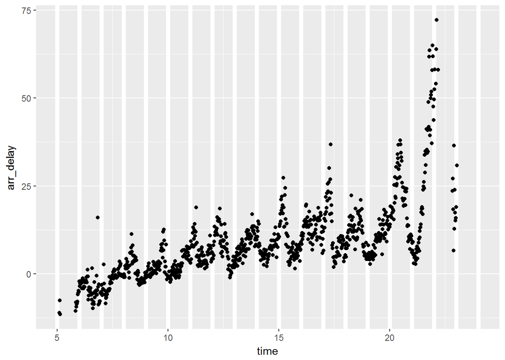

```r
# data manipulation and plotting
ggplot(filter(per_hour, n > 30), aes(time, arr_delay)) +
  geom_vline(xintercept = 5:24, colour = "white", size = 2) +
  geom_point()
```

```r
flights %>%
group_by(carrier, flight, dest) %>%
tally(sort = TRUE) %>% # Save some typing
filter(n == 365)
```

```
## Source: local data frame [7 x 4]
## Groups: carrier, flight [7]
##
##   carrier flight  dest     n
##     <chr>  <int> <chr> <int>
## 1      AA   1294   MIA   365
## 2      AS    731   SEA   365
## 3      CO      1   HNL   365
## 4      CO     62   EWR   365
## 5      CO     89   EWR   365
## 6      CO    106   EWR   365
## 7      MQ   3859   ORD   365
```

```r
flights %>%
group_by(carrier, flight, dest) %>%
summarise(n = n()) %>%
arrange(desc(n)) %>%
filter(n == 365)
```

```
## Source: local data frame [7 x 4]
## Groups: carrier, flight [7]
##
##   carrier flight  dest     n
##     <chr>  <int> <chr> <int>
## 1      AA   1294   MIA   365
## 2      AS    731   SEA   365
## 3      CO      1   HNL   365
## 4      CO     62   EWR   365
## 5      CO     89   EWR   365
## 6      CO    106   EWR   365
## 7      MQ   3859   ORD   365
```

## Two table verbs

If we want to show flight delays on a map, we need to connect the flight information data to the airport data set, which contains geographical information on the different airports.  
In order to connect two data tables we can sue the join() verbs:

| Type | Action |
| --- | --- |
| inner | include only rows in **both** data tables x and y |
| left | include all of x , and matching rows of y |
| semi | include rows of x that match y |
| anti | include rows of x that **don’t** match y |
| full | retain all rows |
| right | include all of y, and matching rows of x |

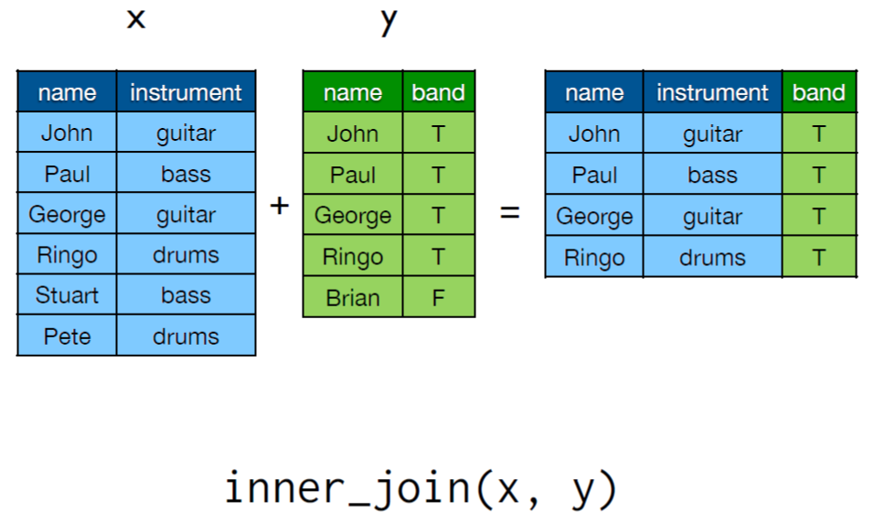

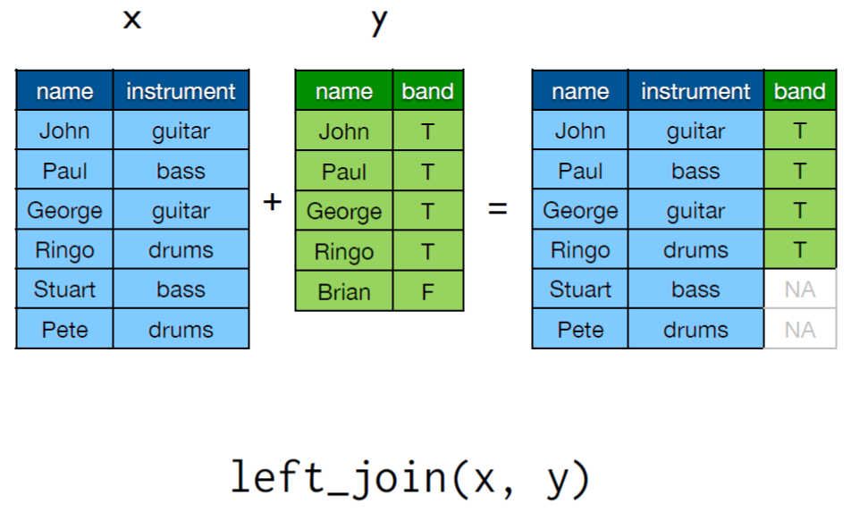

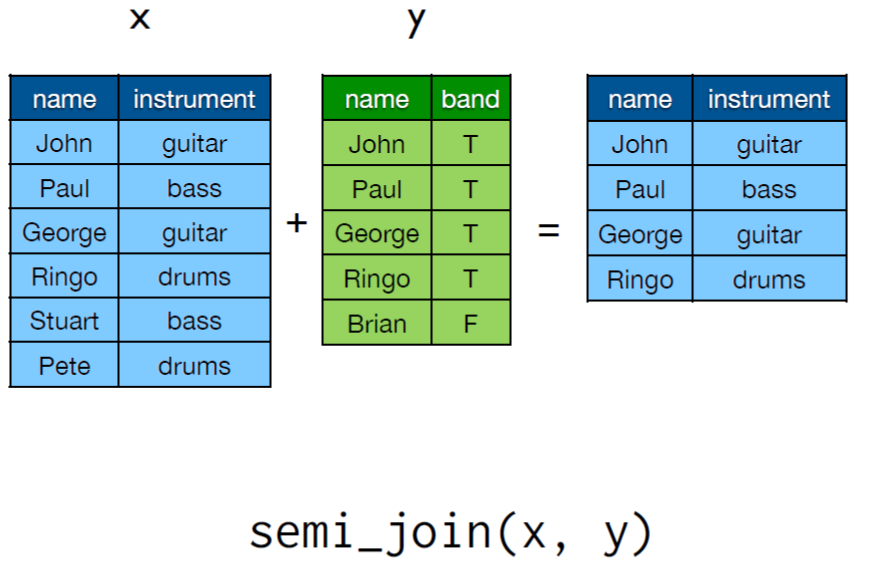

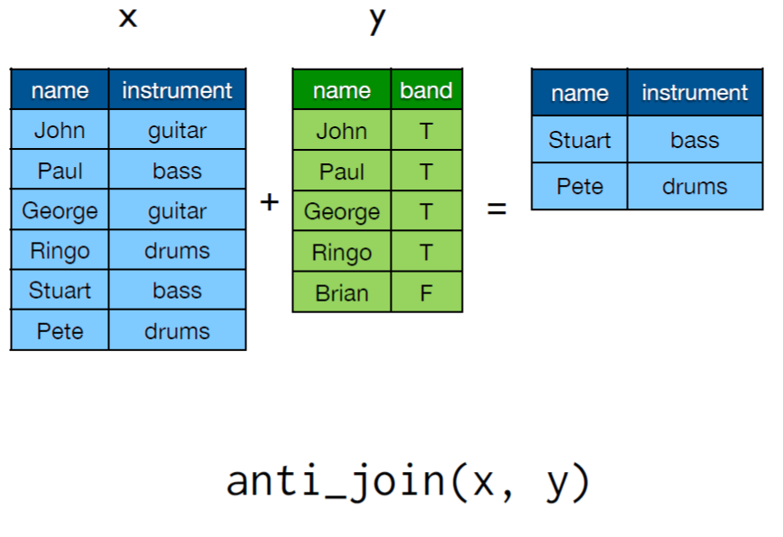

```r
location <- airports %>%
select(dest = iata, name = airport, lat, long)

flights %>%
group_by(dest) %>%
filter(!is.na(arr_delay)) %>%
summarise(
arr_delay = mean(arr_delay),
n = n()
) %>%
arrange(desc(arr_delay)) %>%
left_join(location)
```

```
## # A tibble: 116 × 6
##     dest arr_delay     n                                name      lat
##    <chr>     <dbl> <int>                               <chr>    <dbl>
## 1    ANC  26.08065   124 Ted Stevens Anchorage International 61.17432
## 2    CID  17.80049   406                       Eastern Iowa  41.88459
## 3    DSM  15.95110   634            Des Moines International 41.53493
## 4    SFO  14.89036  2800         San Francisco International 37.61900
## 5    BPT  14.33333     3            Southeast Texas Regional 29.95083
## 6    GRR  13.71729   665           Kent County International 42.88082
## 7    DAY  13.67117   444             James M Cox Dayton Intl 39.90238
## 8    VPS  12.45718   864                Eglin Air Force Base 30.48325
## 9    ECP  12.42222   720                                <NA>       NA
## 10   SAV  12.33137   851              Savannah International 32.12758
## # ... with 106 more rows, and 1 more variables: long <dbl>
```

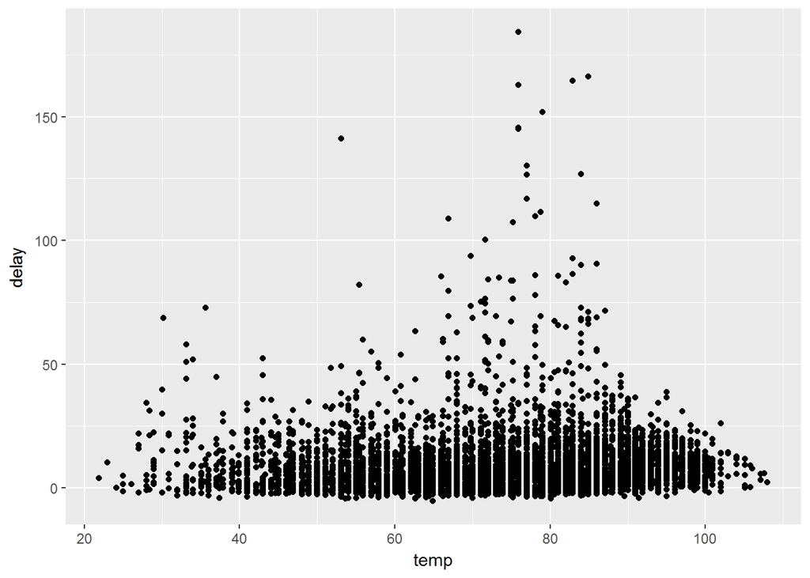

```r
hourly_delay <- flights %>%
group_by(date, hour) %>%
filter(!is.na(dep_delay)) %>%
summarise(
delay = mean(dep_delay),
n = n()
) %>%
filter(n > 10)
delay_weather <- hourly_delay %>% left_join(weather)

qplot(temp, delay, data = delay_weather)
```

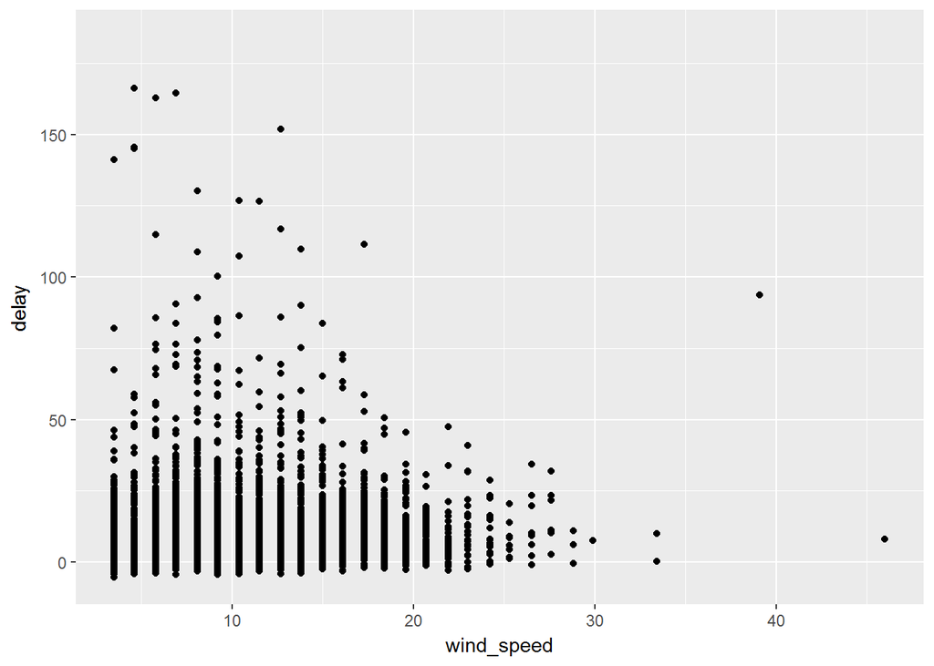

```r
qplot(wind_speed, delay, data = delay_weather)
```

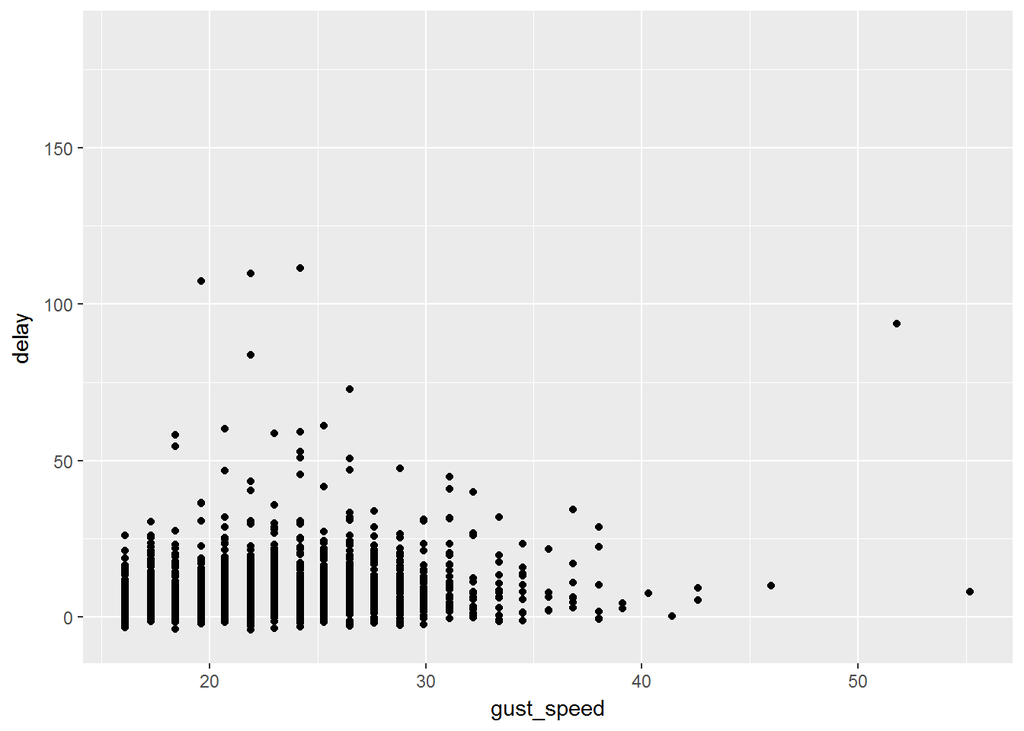

```r
qplot(gust_speed, delay, data = delay_weather)
```

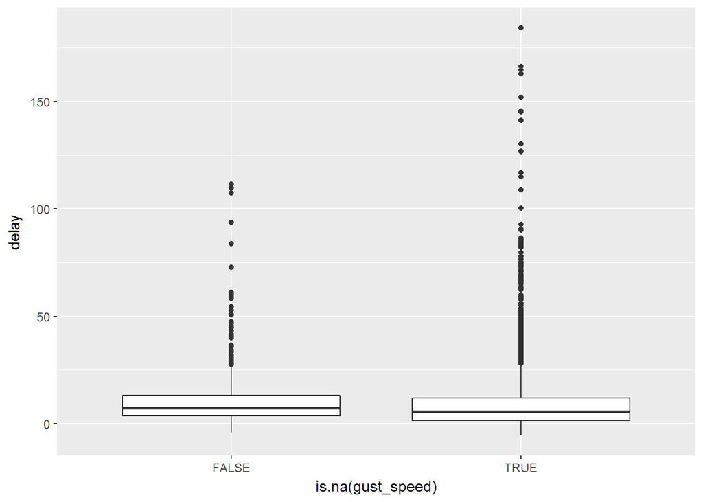

```r
qplot(is.na(gust_speed), delay, data = delay_weather,
geom = "boxplot")
```

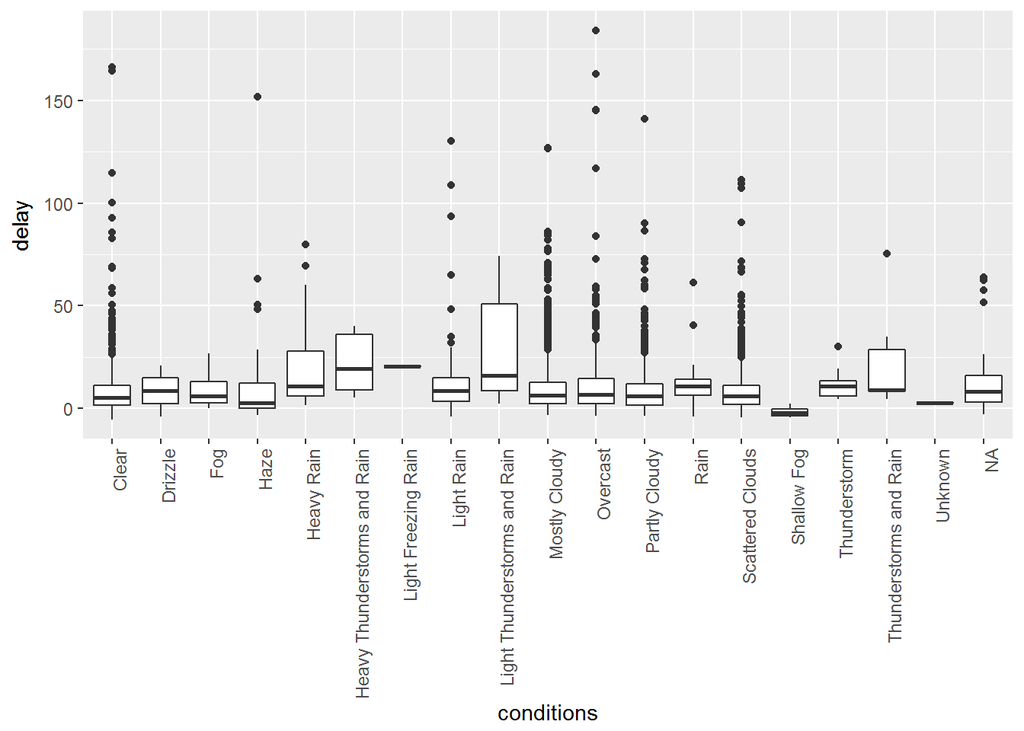

```r
qplot(conditions, delay, data = delay_weather,
geom = "boxplot") + theme(axis.text.x = element_text(angle = 90, hjust = 1))
```

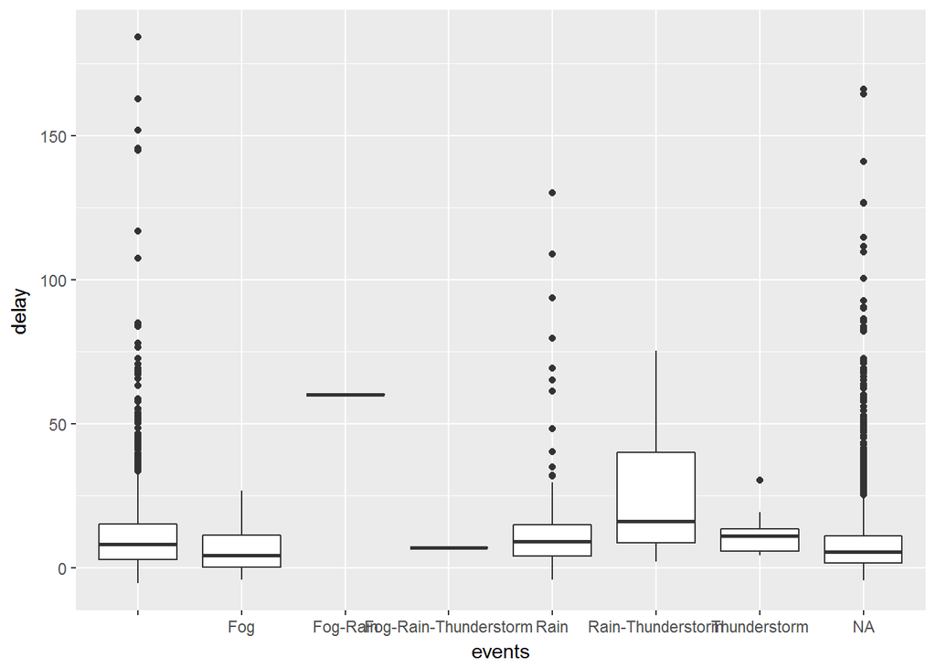

```r
qplot(events, delay, data = delay_weather,
geom = "boxplot")
```

In case you want to do something that is not covered by any of the basic verbs you can use do(). It’s slower, but adjustable to any purpose you specify, which can be very handy when using models. It’s equivalent to ddply() and dlply().

```r
# The aim is to fit a linear model to each day, predicting
# delay from time of day

usual <- flights %>%
mutate(time = hour + minute / 60) %>%
filter(hour >= 5, hour <= 20)

models <- usual %>%
group_by(date) %>%
do(
mod = lm(dep_delay ~ time, data = .)
)

# source causes R to accept its input from the named file or URL or connection. Input is read and parsed from that file until the end of the file is reached, then the parsed expressions are evaluated sequentially in the chosen environment.
# source("filename.R")
```